# STAT UN2103 HW4

Rebekah Kim

November 23, 2016

### Problem 1 (handwritten in back)

### Problem 2

```r
d <- read.table("HW4Problem2.txt", header = TRUE)

model <- lm(RentalRates~Age+OperatingExpense+VacancyRates+SquareFootage, data = d)
summary(model)
```

```
##
## Call:
## lm(formula = RentalRates ~ Age + OperatingExpense + VacancyRates +
##     SquareFootage, data = d)
##
## Residuals:
##     Min      1Q  Median      3Q     Max
## -3.1872 -0.5911 -0.0910  0.5579  2.9441
##
## Coefficients:
##                    Estimate Std. Error t value Pr(>|t|)
## (Intercept)       1.220e+01  5.780e-01  21.110  < 2e-16 ***
## Age              -1.420e-01  2.134e-02  -6.655 3.89e-09 ***
## OperatingExpense  2.820e-01  6.317e-02   4.464 2.75e-05 ***
## VacancyRates      6.193e-01  1.087e+00   0.570     0.57
## SquareFootage     7.924e-06  1.385e-06   5.722 1.98e-07 ***
## ---
## Signif. codes:  0 '***' 0.001 '**' 0.01 '*' 0.05 '.' 0.1 ' ' 1
##
## Residual standard error: 1.137 on 76 degrees of freedom
## Multiple R-squared:  0.5847, Adjusted R-squared:  0.5629
## F-statistic: 26.76 on 4 and 76 DF,  p-value: 7.272e-14
```

$t_{calc} = 0.570, p-value = 0.57 > 0.05$

We fail to reject the null hypothesis; therefore, x3 (vacancy rate) is not a statistically predictor to the response variable (rental rates) after holding all other variables constant.

$H_0 : \beta_1 = \beta_3 = 0, \space H_A : \beta_1 \neq 0 \space or \space \beta_3 \neq 0$

Full model: $Y_i = \beta_0 + \beta_1x_{i1}+ \beta_2x_{i2}+ \beta_3x_{i3}+ \beta_4x_{i4}+ \epsilon_i$

$df_F = n - p = n - 5 = 81 - 5 = 76$

Reduced model: $Y_i = \beta_0 + \beta_2x_{i2}+ \beta_4x_{i4}+ \epsilon_i$

$df_R = n - p = n - 3 = 81 - 3 = 78$

```r
r_model.1 <- lm(RentalRates~OperatingExpense+SquareFootage, data = d)
```

$f_{calc} = \dfrac{SSE_R - SSE_F}{df_R - df_F} \div \dfrac{SSE_F}{df_F}$

```r
#Shortcut
anova(r_model.1, model)
```

```
## Analysis of Variance Table
##
## Model 1: RentalRates ~ OperatingExpense + SquareFootage
## Model 2: RentalRates ~ Age + OperatingExpense + VacancyRates + SquareFootage
##   Res.Df     RSS Df Sum of Sq      F    Pr(>F)
## 1     78 159.491
## 2     76  98.231  2    61.261 23.698 1.003e-08 ***
## ---
## Signif. codes:  0 '***' 0.001 '**' 0.01 '*' 0.05 '.' 0.1 ' ' 1
```

$SSE_F = 98.231$

$SSE_R = 159.491$

Therefore we reject the null hypothesis; age (x1) or vacancy rate (x3) may influence the rental rates.

$H_0 : \beta_3 = 0, \space H_A : \beta_3 \neq 0$

Full model: $Y_i = \beta_0 + \beta_1x_{i1}+ \beta_2x_{i2}+ \beta_3x_{i3}+ \beta_4x_{i4}+ \epsilon_i$

$df_F = n - p = n - 5 = 81 - 5 = 76$

Reduced model: $Y_i = \beta_0 + \beta_1x_{i1}+ \beta_2x_{i2}+ \beta_4x_{i4}+ \epsilon_i$

$df_R = n - p = n - 4 = 81 - 4 = 77$

```r
r_model.2 <- lm(RentalRates~Age+OperatingExpense+SquareFootage, data = d)
```

$f_{calc} = \dfrac{SSE_R - SSE_F}{df_R - df_F} \div \dfrac{SSE_F}{df_F}$

```r
#Shortcut
anova(r_model.2, model)
```

```
## Analysis of Variance Table
##
## Model 1: RentalRates ~ Age + OperatingExpense + SquareFootage
## Model 2: RentalRates ~ Age + OperatingExpense + VacancyRates + SquareFootage
##   Res.Df    RSS Df Sum of Sq      F Pr(>F)
## 1     77 98.650
## 2     76 98.231  1   0.41975 0.3248 0.5704
```

$SSE_F = 98.231$

$SSE_R = 98.650$

$f_{calc} = 0.3248, \space p-value = 0.5704 > 0.05$

Therefore, we fail to reject the null hypothesis; vacancy rate (x3) is not a statistically signficant predictor for the response variable (rental rates) after holding all other variables constant.

The f-calc and p-value (0.57) here are the same as that of the t-test (f = t^2 ; 0.3248 = 0.57^2) from part (i) as expected and therefore we reach the same conclusion: fail to reject null hypothesis.

$H_0 : \beta_3 = 0, \space H_A : \beta_3 \neq 0$

```r
model_t1 <- lm(RentalRates~Age+OperatingExpense+SquareFootage+VacancyRates, data = d)

anova(model_t1)
```

```
## Analysis of Variance Table
##
## Response: RentalRates
##                  Df Sum Sq Mean Sq F value    Pr(>F)
## Age               1 14.819  14.819 11.4649  0.001125 **
## OperatingExpense  1 72.802  72.802 56.3262 9.699e-11 ***
## SquareFootage     1 50.287  50.287 38.9062 2.306e-08 ***
## VacancyRates      1  0.420   0.420  0.3248  0.570446
## Residuals        76 98.231   1.293
## ---
## Signif. codes:  0 '***' 0.001 '**' 0.01 '*' 0.05 '.' 0.1 ' ' 1
```

$f_{calc} = 0.3248, \space p-value = 0.5704 > 0.05$

We fail to reject the null hypothesis; vacancy rates (x3) is not a statistically significant predictor of rental rates (y) after holding other variables constant. The f-calc and p-value (0.57) here are the same as that of the t-test (f = t^2 ; 0.3248 = 0.57^2) from part (i) and that of the F-test from part (iii) as expected and therefore we reach the same conclusion: fail to reject null hypothesis.

```r
x.h <- data.frame(Age = c(5,6,14,12), OperatingExpense = c(8.25, 8.5, 11.5, 10.25), VacancyRates = c(0, 0.23, 0.11, 0), SquareFootage = c(250000, 270000, 300000, 310000))

predict(model, x.h, interval = "confidence", level = 1 - 0.5/4)
```

```
##        fit      lwr      upr
## 1 15.79813 15.36676 16.22950
## 2 16.02754 15.66156 16.39351
## 3 15.90072 15.55610 16.24534
## 4 15.84339 15.44142 16.24535
```

1. (15.36676, 16.22950)
2. (15.66156, 16.39351)
3. (15.55610, 16.24534)
4. (15.44142, 16.24535)

### Problem 3

```r
d_2 <- read.table("HW4Problem3.txt", header = TRUE)

model <- lm(y~x, data = d_2)
summary(model)
```

```
##
## Call:
## lm(formula = y ~ x, data = d_2)
##
## Residuals:
##      Min       1Q   Median       3Q      Max
## -22.7723  -3.7371   0.3334   6.3334  15.4039
##
## Coefficients:
##             Estimate Std. Error t value Pr(>|t|)
## (Intercept)  -0.5802     2.8039  -0.207    0.837
## x            15.0352     0.4831  31.123   <2e-16 ***
## ---
## Signif. codes:  0 '***' 0.001 '**' 0.01 '*' 0.05 '.' 0.1 ' ' 1
##
## Residual standard error: 8.914 on 43 degrees of freedom
## Multiple R-squared:  0.9575, Adjusted R-squared:  0.9565
## F-statistic: 968.7 on 1 and 43 DF,  p-value: < 2.2e-16
```

$y = -0.5802 + 15.0352x$

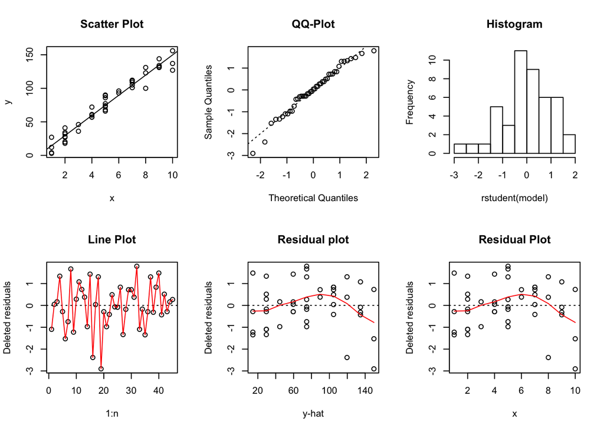

```r
n <- length(d_2[,1])

par(mfrow=c(2,3))

plot(d_2$x,d_2$y, main="Scatter Plot", xlab = "x", ylab = "y")
abline(a =  -0.5802, b = 15.0352)

qqnorm(rstudent(model), main = "QQ-Plot")
abline(a=0, b=1,lty=3)

hist(rstudent(model), main = "Histogram")

plot(1:n, rstudent(model), main = "Line Plot", ylab="Deleted residuals")
abline(h = 0, lty = 3)
lines(1:n,rstudent(model),col=2)

plot(predict(model), rstudent(model), main= "Residual plot", xlab = "y-hat", ylab = "Deleted residuals")
abline(h = 0, lty = 3)
lines(supsmu(predict(model), rstudent(model)), col=2)

plot(d_2$x, rstudent(model), main = "Residual Plot", xlab = "x", ylab = "Deleted residuals")
abline(h = 0, lty = 3)
lines(supsmu(d_2$x, rstudent(model)), col = 2)
```

Since the graphs are not crystal clear, there can be subjective judgments. This is what I see: the scatter plot seems to suggest that the response function is linear (clear linear pattern). The QQ-plot suggests that is is safe to assume normality of the error (relatively lines up well in the 45 degree line). It is a bit heavy-tailed on the left; there are some potential outliers that deviate from the 45 degree line, but generally seems to land on the line. The line plot shows that it would not be unreasonable to assume the errors are independent; there is no clear pattern and it seems like white noise. It is a bit difficult to decide the homoscedasticity of the data. The residual plots show that fluctuations in the deleted residual’s overall shape; the scatters seem to get wider towards the right, having a small megaphone shape from the middle to the right section of the plot. If this is true, there would be no constance in error variance. However, these fluctuations may be due to random chance and the errors may have constant variance.

```r
library(MASS)
x <- d_2$x
y <- d_2$y
bac.box <-  boxcox(y~x)
```

[figure not shown]

```r
bac.lambda <-  bac.box$x[which(bac.box$y==max(bac.box$y))]
bac.lambda
```

```
## [1] 1.111111
```

It probably wouldn’t be necessary to perform this transformation since lambda is close to 1 and its interval includes 1. The plots from part ii) already reasonably resemble a linear relationship between x and y.

### Problem 4

$H_0 : E[Y] = \beta_0 + \beta_1x \space H_A : E[Y] \neq \beta_0 +\beta_1x$

```r
d_3 <- read.table("1_22.txt")

x <- d_3$V2
y <- d_3$V1
n <- length(y)
c <- 4

sse.R <- anova(lm(y~x))[[2]][2]
fac.x <- factor(x)
sse.F <- anova(lm(y~fac.x))[[2]][2]
f.calc <- ((sse.R - sse.F)/(c-2))/(sse.F/(n-c))
f.calc
```

```
## [1] 0.8236893
```

```r
1-pf(f.calc, c-2, n-c)
```

```
## [1] 0.4621597
```

$f_{calc} = 0.8237 \space p-value = 0.4622 > 0.05$

Therefore we fail to reject the null hypothesis; there may be a linear relationship between the elapsed time (x) and the hardness of the plastic (y). A linear relationship is probably appropriate for this dataset as further illustrated in the plot below.

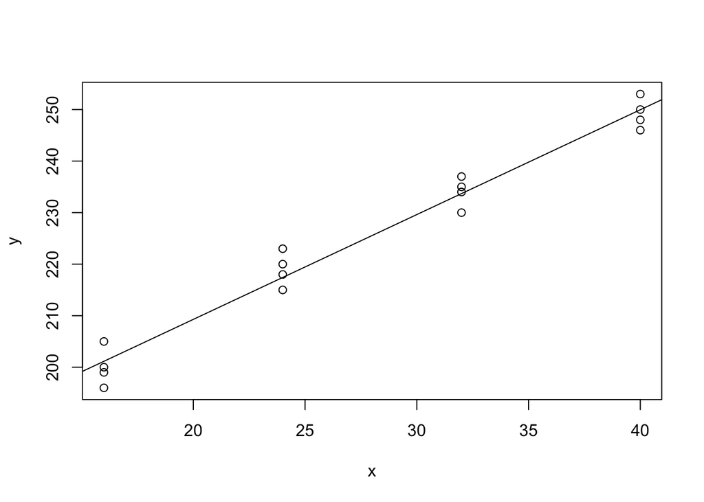

```r
plot(x, y)
abline(lm(y~x))
```

### Problem 5 (handwritten in back)